## Homework 5

#### The first step is to read in the data.

```r
dat<-read.csv("homework5.csv")
```

#### The next step is to check the structure of the data.

```r
str(dat)
```

```
## 'data.frame':    64 obs. of  2 variables:
##  $ music: Factor w/ 2 levels "metal","none": 2 2 2 2 2 2 2 2 2 2 ...
##  $ wpm  : num  23.5 44.1 42.3 24.4 42.8 ...
```

#### The dat shows that there are two variables; music (metal and none) and wpm.

#### Now I will find the mean words per minute for the two levels of music; metal and none.

```r
mean(dat$wpm[dat$music=="metal"])
```

```
## [1] 48.03665
```

```r
mean(dat$wpm[dat$music=="none"])
```

```
## [1] 42.44641
```

#### The test showed that for metal the mean of wpm = 48.04

#### The test showed that for none the mean of wpm = 42.45.

#### In comparing the means, it appears that the metal group had higher wpm.

#### I will now run an independent t-test to determine if there is a difference in the mean of wpm in the two groups; metal and none.

```r
t.test(dat$wpm[dat$music=="metal"],
       dat$wpm[dat$music=="none"],
       var.equal=TRUE)
```

```
##
##  Two Sample t-test
##
## data:  dat$wpm[dat$music == "metal"] and dat$wpm[dat$music == "none"]
## t = 2.3317, df = 62, p-value = 0.02298
## alternative hypothesis: true difference in means is not equal to 0
## 95 percent confidence interval:
##   0.7977514 10.3827312
## sample estimates:
## mean of x mean of y
##  48.03665  42.44641
```

#### The t-test determined that the metal group was in fact significantly faster in wpm than the none group.

#### t(62) = 2.33, p = .02298

#### I will now run a second independent t-test using the alternative hypothesis that the metal group has higher wpm than the none group.

```r
t.test(dat$wpm[dat$music=="metal"],
       dat$wpm[dat$music=="none"],
       var.equal=TRUE,
       alternative="greater")
```

```
##
##  Two Sample t-test
##
## data:  dat$wpm[dat$music == "metal"] and dat$wpm[dat$music == "none"]
## t = 2.3317, df = 62, p-value = 0.01149
## alternative hypothesis: true difference in means is greater than 0
## 95 percent confidence interval:
##  1.586923      Inf
## sample estimates:
## mean of x mean of y
##  48.03665  42.44641
```

#### The t-test verifies that the metal group has faster wpm than the none group.

#### t(62) = 2.33, p = .01149

#### I need to load ggplot2, gplots, and dplyr libraries in order to create a figure of the data.

```r
library(ggplot2)
library(gplots)
library(dplyr)
```

#### Then I will use dplyr to summarize the information and find the means and standard errors of the means for both groups.

```r
temp<-dat%>%group_by(music)%>%
  summarize(means=mean(wpm), sems=sd(wpm)/sqrt(length(wpm)))
```

#### Metal means = 48.04, sems = 1.76

#### None means = 42.45, sems = 1.63

#### I will then create a figure from this data.

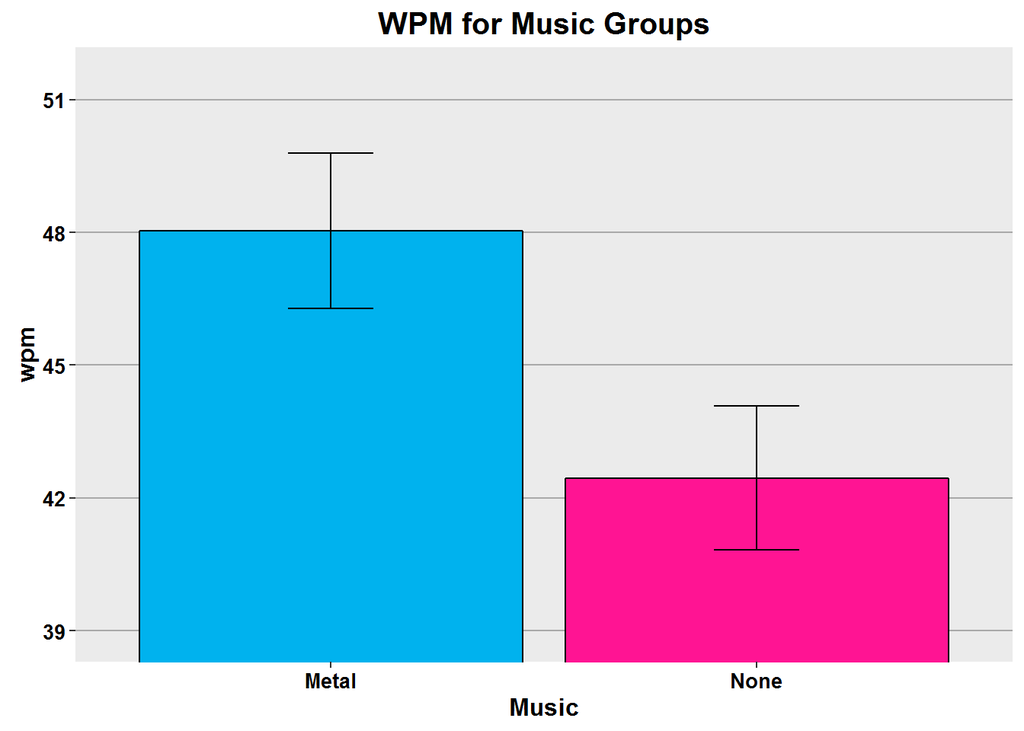

```r
f<-ggplot(temp,aes(x=factor(music),y=means))+
  geom_bar(stat="identity", color="black",
           fill=c("deepskyblue2", "deeppink"))+
  geom_errorbar(aes(ymax=means+sems,
                    ymin=means-sems),
                width=.2)+
  ggtitle("WPM for Music Groups")+
  labs(x="Music", y="wpm")+
  scale_x_discrete(breaks=c("metal","none"),
                   labels=c("Metal","None"))+
  theme(plot.title=element_text(size=15,
                                face="bold",
                                vjust=.5))+
  theme(axis.title.x=element_text(size=12,
                                  face="bold",
                                  vjust=-.25))+
  theme(axis.title.y=element_text(size=12,
                                  face="bold",
                                  vjust=.25))+
  theme(axis.text.x=element_text(size=10,
                                 face="bold",
                                 color="black"))+
  theme(axis.text.y=element_text(size=10,
                                 face="bold",
                                 color="black"))+
  coord_cartesian(ylim=c(min(temp$means)-2*max(temp$sems),
                         max(temp$means)+2*max(temp$sems)))+
  theme(panel.border=element_blank(),
        axis.line=element_line())+
  theme(panel.grid.major.x=element_blank())+
  theme(panel.grid.major.y=element_line(color="darkgrey"))+
  theme(panel.grid.minor.y=element_blank())
f
```

#### The final test is a two-tailed paired t-test.

```r
t.test(dat$wpm[dat$music=="metal"],
       dat$wpm[dat$music=="none"],
       var.equal=TRUE,
       paired=TRUE)
```

```
##
##  Paired t-test
##
## data:  dat$wpm[dat$music == "metal"] and dat$wpm[dat$music == "none"]
## t = 12.153, df = 31, p-value = 2.51e-13
## alternative hypothesis: true difference in means is not equal to 0
## 95 percent confidence interval:
##  4.652093 6.528390
## sample estimates:
## mean of the differences
##                5.590241
```

#### This test showed that those in the metal group had a faster wpm than the none group.

#### t(31) = 12.153, p < 0.05